# BGC Argo data workshop (example)

## Workshop overview

Loading libraries

Fetching and loading Data

Filtering QC

Plotting data transect

Plotting profiles

Getting data from multiple floats in a giver region

[figure not shown]

## Loading Libraries

```python
# Loading libraries
import pandas as pd #A library for tabular data manipulation and analysis
import argopy as ar #A library for accessing and working with Argo float data, used here to download and process the synthetic profile data.
import numpy as np #A library for numerical operations, used here for array manipulations and calculations.
import xarray as xr #A library for working with labeled multi-dimensional arrays, used here to handle the Argo profile data in a structured format.
import matplotlib.pyplot as plt #A library for creating static, animated, and interactive visualizations in Python, used here to plot the Argo profile data.
from matplotlib.colors import LogNorm #A class for normalizing data on a logarithmic scale, used here to enhance the visualization of the Argo profile data when plotting.
from matplotlib.ticker import LogLocator #A class for locating ticks on a logarithmic scale, used here to set the tick locations when plotting the Argo profile data on a logarithmic scale.
```

### Xarray data structures

Xarray has two fundamental data structures:

a DataArray, which holds a single multi-dimensional variable and its coordinates

a Dataset, which holds multiple variables that potentially share the same coordinates  
**DataArray**  
A DataArray has four essential attributes:

*values*: a numpy.ndarray holding the array’s values *dims*: dimension names for each axis (e.g., ('x', 'y', 'z')) *coords*: a dict-like container of arrays (coordinates) that label each point (e.g., 1-dimensional arrays of numbers, datetime objects or strings) *attrs*: an OrderedDict to hold arbitrary metadata (attributes)

[figure not shown]

## Fetching data

The BGC-Argo data files are store on the Global Data Assembly Centre (GDAC) following a specific data storage architecture.

Each Data assembly centre has its own repertory that contains as many folder as there are floats. In each float folder you will find different NetCDF data files

- **Rtraj** Provide information on the position of the float, its cycling pattern and other useful metadata
- **meta** Contains all the metadata of the float
- **Sprof** This is the most useful file for most scientific usage. It's a concatenation of all the profiles with all the observed variables.
- **tech** Is a summary of the technical, engineering specs of the floats, like battery consumption or autonomy.
- **profils/** This repertory has all the profiles in separate NetCDF, it can be useful for specific needs, but we won't cover this in this workshop

[figure not shown]

### But how do we find a specific file ?

When we want to download data from the float array, we want to be able to query all the float in specific location or with a specific payload. And even when we know which float data we want to download we don't necesseraly know in which DAC folder it is stored.

To find your way in the data archive you need to download the Bio-Index file, which is a table listing all the float profile with their longitude, latitude, date, payload and the path of the data file in the GDAC.

We can download it with this simple utility function

```python
import os #A library for interacting with the operating system, used here to handle file paths and directories.
import requests #A library for making HTTP requests, used here to download the synthetic profile index file from the specified URL.

#Provide the URL where the synthetic profile index file is located, the URL for the DAC, the local directory to save the data, and the filename to save as. Then, download the file and save it to the specified location.
host = 'https://data-argo.ifremer.fr/argo_synthetic-profile_index.txt'
dac = 'https://data-argo.ifremer.fr/dac'
data_directory = 'Data'
filename = 'synth_file.txt'
destination = os.path.join(data_directory, filename)

#setting data directory of DSP
if not os.path.exists(data_directory):
    os.makedirs(data_directory)

response = requests.get(host, stream=True)

with open(destination, "wb") as f:
    r = requests.get(host)
    f.write(r.content)
    print(f"File downloaded and saved to {destination}")
```

```
File downloaded and saved to Data\synth_file.txt
```

You can now have a look at the file.

I'm using the read_csv function from pandas as the synth file is structured in a tabular format.

```python
index_file = pd.read_csv('../Data/synth_file.txt', sep=',', skiprows=8)

#Use the head() method to display the first few rows of the index file, which contains metadata about the synthetic profiles available for download.
index_file.head()
```

|  | file | date | latitude | longitude | ocean | profiler_type | institution | parameters | parameter_data_mode | date_update |
| --- | --- | --- | --- | --- | --- | --- | --- | --- | --- | --- |
| 0 | aoml/1900722/profiles/SD1900722_001.nc | 2.006102e+13 | -40.316 | 73.389 | I | 846 | AO | PRES TEMP PSAL DOXY | DDDD | 20220628080801 |
| 1 | aoml/1900722/profiles/SD1900722_002.nc | 2.006110e+13 | -40.390 | 73.528 | I | 846 | AO | PRES TEMP PSAL DOXY | DDDD | 20220628080813 |
| 2 | aoml/1900722/profiles/SD1900722_003.nc | 2.006111e+13 | -40.455 | 73.335 | I | 846 | AO | PRES TEMP PSAL DOXY | DDDD | 20220628080826 |
| 3 | aoml/1900722/profiles/SD1900722_004.nc | 2.006112e+13 | -40.134 | 73.080 | I | 846 | AO | PRES TEMP PSAL DOXY | DDDD | 20220628080839 |
| 4 | aoml/1900722/profiles/SD1900722_005.nc | 2.006120e+13 | -39.641 | 73.158 | I | 846 | AO | PRES TEMP PSAL DOXY | DDDD | 20220628080852 |

So, technically, we can now make any request on that table t o find the float profiles that would be interesting to us and use the "file" columns to find the ftp adress to download the file.

It sounds a bit cumbersome, doesn't it ?

happilty for us, a packahe has recently been developped that will make our life easier.

### Argopy

We will use the Argopy library to fetch and load data from a BGC Argo float. The documentation is available at [Argopy documentation](https://argopy.readthedocs.io/en/latest/).

We can directly load the Sprof file of any BGC-Argo float in memory, simply by calling a `ar.ArgoFloat` class which will fetch the data from the GDAC.

The WMO argument will allow us to specify which float we want to use.

```python
# example of sensor issue with bad Qc result WMO = 5907147
WMO = 3901586
#The ar.ARgofloat class is used to create an instance of an Argo float with the specified WMO number.
# The open_dataset method is then called with the argument "Sprof" to access the synthetic profile data for that float, which is stored in the variable argo_ds as an xarray Dataset.
argo_ds = ar.ArgoFloat(WMO).open_dataset("Sprof")
```

So, now the argo_ds is the xarray object containing the Sprof data of the WMo we provided. We can easily visualise the file structure using the `xr.display` function.

```python
display(argo_ds)
```

```
<xarray.Dataset> Size: 101MB
Dimensions:                            (N_PROF: 122, N_PARAM: 14, N_CALIB: 1,
                                        N_LEVELS: 2334)
Dimensions without coordinates: N_PROF, N_PARAM, N_CALIB, N_LEVELS
Data variables: (12/128)
    DATA_TYPE                          <U32 128B ...
    FORMAT_VERSION                     <U4 16B ...
    HANDBOOK_VERSION                   <U4 16B ...
    REFERENCE_DATE_TIME                datetime64[ns] 8B ...
    DATE_CREATION                      datetime64[ns] 8B ...
    DATE_UPDATE                        datetime64[ns] 8B ...
    ...                                 ...
    NITRATE                            (N_PROF, N_LEVELS) float32 1MB ...
    NITRATE_QC                         (N_PROF, N_LEVELS) int32 1MB ...
    NITRATE_dPRES                      (N_PROF, N_LEVELS) float32 1MB ...
    NITRATE_ADJUSTED                   (N_PROF, N_LEVELS) float32 1MB ...
    NITRATE_ADJUSTED_QC                (N_PROF, N_LEVELS) int32 1MB ...
    NITRATE_ADJUSTED_ERROR             (N_PROF, N_LEVELS) float32 1MB ...
Attributes:
    title:                Argo float vertical profile
    institution:          BODC
    source:               Argo float
    history:              2026-03-07T16:07:13Z creation (software version 1.2...
    references:           http://www.argodatamgt.org/Documentation
    user_manual_version:  1.0
    Conventions:          Argo-3.1 CF-1.6
    featureType:          trajectoryProfile
    software_version:     1.20 (version 12.05.2025 for ARGO_simplified_profile)
    id:                   https://doi.org/10.17882/42182
```

Great, we have found the full BGC data for this float.

We can see that the profile number *N_PROF* and the depth level *N_LEVELS* are two of the dimensions. This will be useful later on to visualise and extract data.

## Checking QC

The argo is using a standardised data quality control framework. Each QC test can be found in the different variables cookbook and the result is stored in a controled QC vocabulary scheme.

[figure not shown]

```python
argo_ds = argo_ds.rename({'CYCLE_NUMBER':'PROF_NUM'}).swap_dims({'N_PROF':'PROF_NUM'})
display(argo_ds)
```

```
<xarray.Dataset> Size: 101MB
Dimensions:                            (PROF_NUM: 122, N_PARAM: 14, N_CALIB: 1,
                                        N_LEVELS: 2334)
Coordinates:
  * PROF_NUM                           (PROF_NUM) int32 488B 1 1 2 ... 119 120
Dimensions without coordinates: N_PARAM, N_CALIB, N_LEVELS
Data variables: (12/127)
    DATA_TYPE                          <U32 128B ...
    FORMAT_VERSION                     <U4 16B ...
    HANDBOOK_VERSION                   <U4 16B ...
    REFERENCE_DATE_TIME                datetime64[ns] 8B ...
    DATE_CREATION                      datetime64[ns] 8B ...
    DATE_UPDATE                        datetime64[ns] 8B ...
    ...                                 ...
    NITRATE                            (PROF_NUM, N_LEVELS) float32 1MB ...
    NITRATE_QC                         (PROF_NUM, N_LEVELS) int32 1MB ...
    NITRATE_dPRES                      (PROF_NUM, N_LEVELS) float32 1MB ...
    NITRATE_ADJUSTED                   (PROF_NUM, N_LEVELS) float32 1MB ...
    NITRATE_ADJUSTED_QC                (PROF_NUM, N_LEVELS) int32 1MB ...
    NITRATE_ADJUSTED_ERROR             (PROF_NUM, N_LEVELS) float32 1MB ...
Attributes:
    title:                Argo float vertical profile
    institution:          BODC
    source:               Argo float
    history:              2026-03-07T16:07:13Z creation (software version 1.2...
    references:           http://www.argodatamgt.org/Documentation
    user_manual_version:  1.0
    Conventions:          Argo-3.1 CF-1.6
    featureType:          trajectoryProfile
    software_version:     1.20 (version 12.05.2025 for ARGO_simplified_profile)
    id:                   https://doi.org/10.17882/42182
```

[figure not shown]

```python
# Stack NumPy array of datetimes to create a 2D grid
time_2D = np.tile(argo_ds['JULD'].values,(len(argo_ds['N_LEVELS']),1)).T

# Function for repetitive parts of plot
def config_depth_section(cbar_label,title):
  plt.ylim([0,250])
  plt.gca().invert_yaxis()
  plt.ylabel('Pressure (dbar)')
  if 'Nitrate' in cbar_label: extend = 'min'
  else:                       extend = 'neither'
  plt.colorbar(label=cbar_label,extend=extend)
  plt.title(title)

# Create subplots
plt.figure(figsize=(16,6))
plt.subplot(2,2,1)
cmap = plt.get_cmap('viridis')
cmap.set_under('0.5')
plt.pcolor(time_2D,argo_ds['PRES'].values,argo_ds['CHLA'].values,cmap=cmap)
config_depth_section('Nitrate (µmol/kg)',"Parameter: 'CHLA'")

plt.subplot(2,2,2)
plt.pcolor(time_2D,argo_ds['PRES'].values,argo_ds['CHLA_QC'].values.astype(float),cmap='Set1',vmin=0.5,vmax=9.5)
config_depth_section('QC flag',"Parameter: 'CHLA_QC'")

plt.subplot(2,2,3)
plt.pcolor(time_2D,argo_ds['PRES'].values,argo_ds['PSAL'].values,cmap=cmap)
config_depth_section('Nitrate (µmol/kg)',"Parameter: 'PSAL'")

plt.subplot(2,2,4)
plt.pcolor(time_2D,argo_ds['PRES'].values,argo_ds['PSAL_QC'].values.astype(float),cmap='Set1',vmin=0.5,vmax=9.5)
config_depth_section('QC flag',"Parameter: 'PSAL_QC'")

plt.tight_layout(h_pad=5,w_pad=3)
```

## Basic plotting

### Mapping

We can first easily visualise the trajectory of the float with a scatter plot.

```python
import cartopy.crs as ccrs
import cartopy
import pandas as pd
from typing import cast
from cartopy.mpl.geoaxes import GeoAxes
import matplotlib.pyplot as plt
import matplotlib.dates as mdates


def plot_argo_trajectory(argo_ds, extent=10):
  import cartopy.feature as cfeature

  dates = pd.to_datetime(argo_ds["JULD"].values)
  date_nums = mdates.date2num(dates)

  lon = argo_ds["LONGITUDE"].values.astype(float)
  lat = argo_ds["LATITUDE"].values.astype(float)
  valid = (~pd.isna(lon)) & (~pd.isna(lat))

  lon = lon[valid]
  lat = lat[valid]
  date_nums = date_nums[valid]

  fig, ax0 = plt.subplots(
    figsize=(10, 10),
    subplot_kw={"projection": ccrs.PlateCarree()},
  )
  ax = cast(GeoAxes, ax0)

  pad = float(extent) if extent is not None else 2.0
  ax.set_extent(
    [lon.min() - pad, lon.max() + pad, lat.min() - pad, lat.max() + pad],
    crs=ccrs.PlateCarree(),
  )

  # Bathymetry-like shaded relief background
  ax.add_feature(cfeature.OCEAN.with_scale("10m"), facecolor="#c6dbef", zorder=0)
  ax.add_feature(cfeature.LAND.with_scale("10m"), facecolor="0.9", zorder=2)
  ax.add_feature(cfeature.COASTLINE.with_scale("10m"), edgecolor="black", linewidth=0.7, zorder=3)

  sc = ax.scatter(
    lon,
    lat,
    c=date_nums,
    cmap="viridis",
    s=25,
    transform=ccrs.PlateCarree(),
    label="Profiles",
    zorder=4,
  )

  cbar = fig.colorbar(sc, ax=ax, orientation="vertical", pad=0.02)
  cbar.set_label("Date of the profile (JULD)")
  cbar.ax.yaxis.set_major_formatter(mdates.DateFormatter("%b %Y"))
  cbar.update_ticks()

  gl = ax.gridlines(draw_labels=True, dms=True, x_inline=False, y_inline=False)
  gl.top_labels = False
  gl.right_labels = False

  ax.legend(loc="lower left")
  ax.set_title(f"Float {argo_ds.PLATFORM_NUMBER[0].astype(str).values} trajectory")
  ax.set_xlabel("Longitude")
  ax.set_ylabel("Latitude")
  plt.show()
```

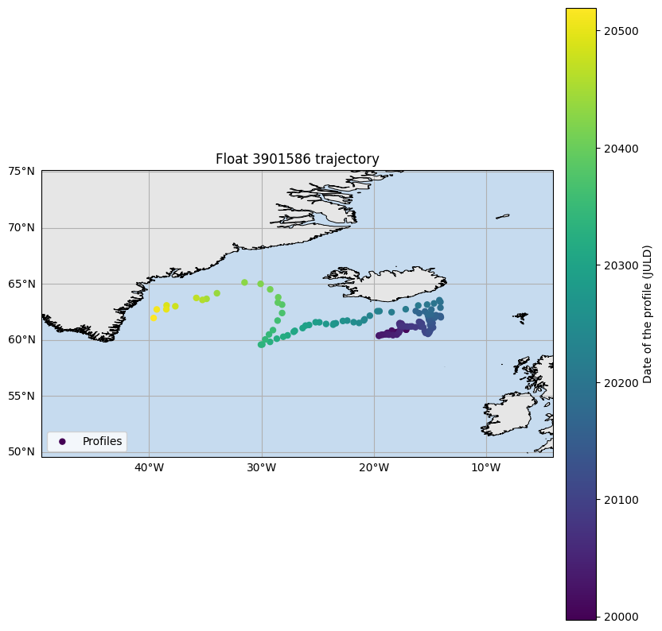

```python
plot_argo_trajectory(argo_ds, extent=10)
```

### Cycle period

An other very important sampling parameter is the time elapsed between two profiles. The standard mission configuration is about 10 days, but you can check the actual cycle period by looking at the time difference between two profiles.

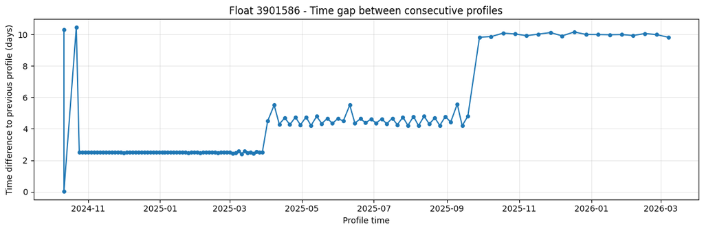

```python
# Build a clean profile-time series
times = pd.to_datetime(argo_ds["JULD"].values)
times = pd.Series(times).dropna().sort_values().reset_index(drop=True)

# Time difference between consecutive profiles (days)
dt_days = times.diff().dt.total_seconds() / 86400.0

# Plot: x = actual profile time, y = time difference to previous profile
fig, ax = plt.subplots(figsize=(12, 4))
ax.plot(times.iloc[1:], dt_days.iloc[1:], "-o", ms=4)
ax.set_xlabel("Profile time")
ax.set_ylabel("Time difference to previous profile (days)")
ax.set_title(f"Float {WMO} - Time gap between consecutive profiles")
ax.grid(True, alpha=0.3)
plt.tight_layout()
plt.show()
```

```python
profile_time_table = (
    pd.DataFrame(
        {
            "PROF_NUM": argo_ds["PROF_NUM"].values,
            "profile_datetime": pd.to_datetime(argo_ds["JULD"].values),
        }
    )
    .dropna(subset=["profile_datetime"])
    .sort_values("profile_datetime")
    .reset_index(drop=True)
)

profile_time_table["elapsed_since_last_profile"] = profile_time_table["profile_datetime"].diff()
profile_time_table["elapsed_since_last_profile_days"] = (
    profile_time_table["elapsed_since_last_profile"].dt.total_seconds() / 86400
).round(3)

profile_time_table
```

|  | PROF_NUM | profile_datetime | elapsed_since_last_profile | elapsed_since_last_profile_days |
| --- | --- | --- | --- | --- |
| 0 | 1 | 2024-10-01 06:31:25.000792576 | NaT | NaN |
| 1 | 1 | 2024-10-11 13:50:24.998305280 | 10 days 07:18:59.997512704 | 10.305 |
| 2 | 2 | 2024-10-11 14:26:59.000759808 | 0 days 00:36:34.002454528 | 0.025 |
| 3 | 2 | 2024-10-22 01:26:44.998124544 | 10 days 10:59:45.997364736 | 10.458 |
| 4 | 3 | 2024-10-24 13:42:24.992623616 | 2 days 12:15:39.994499072 | 2.511 |
| ... | ... | ... | ... | ... |
| 117 | 116 | 2026-01-26 13:28:45.994410496 | 10 days 00:01:59.001691136 | 10.001 |
| 118 | 117 | 2026-02-05 12:03:07.996258304 | 9 days 22:34:22.001847808 | 9.941 |
| 119 | 118 | 2026-02-15 13:36:46.992773632 | 10 days 01:33:38.996515328 | 10.065 |
| 120 | 119 | 2026-02-25 13:30:46.994421248 | 9 days 23:54:00.001647616 | 9.996 |
| 121 | 120 | 2026-03-07 09:14:01.996387328 | 9 days 19:43:15.001966080 | 9.822 |

122 rows × 4 columns

```python
def format_for_transect_plotting(argo_ds, max_depth=1000):
    """
    Prepare Argo profile data for transect plotting on a common pressure grid.
    Returns:
        juld, prei, pres, psal, temp, psali, tempi, chlai
    """
    prei = np.arange(5, max_depth, 5)

    juld = argo_ds["JULD"].values
    pres = argo_ds["PRES"].values
    psal = argo_ds["PSAL"].values if "PSAL" in argo_ds else None
    temp = argo_ds["TEMP"].values if "TEMP" in argo_ds else None
    chla = argo_ds["CHLA"].values if "CHLA" in argo_ds else None

    n_prof = pres.shape[0]
    n_prei = prei.shape[0]

    psali = np.full((n_prof, n_prei), np.nan, dtype=float)
    tempi = np.full((n_prof, n_prei), np.nan, dtype=float)
    chlai = np.full((n_prof, n_prei), np.nan, dtype=float)  # placeholder if CHLA not in `prof`

    for ip in range(n_prof):
        p = pres[ip, :]
        m_p = np.isfinite(p)

        if psal is not None:
            v = psal[ip, :]
            m = m_p & np.isfinite(v)
            if m.sum() > 1:
                pp, vv = p[m], v[m]
                order = np.argsort(pp)
                pp, vv = pp[order], vv[order]
                pp_u, idx = np.unique(pp, return_index=True)
                psali[ip, :] = np.interp(prei, pp_u, vv[idx], left=np.nan, right=np.nan)

        if temp is not None:
            v = temp[ip, :]
            m = m_p & np.isfinite(v)
            if m.sum() > 1:
                pp, vv = p[m], v[m]
                order = np.argsort(pp)
                pp, vv = pp[order], vv[order]
                pp_u, idx = np.unique(pp, return_index=True)
                tempi[ip, :] = np.interp(prei, pp_u, vv[idx], left=np.nan, right=np.nan)
        if chla is not None:
            v = chla[ip, :]
            m = m_p & np.isfinite(v)
            if m.sum() > 1:
                pp, vv = p[m], v[m]
                order = np.argsort(pp)
                pp, vv = pp[order], vv[order]
                pp_u, idx = np.unique(pp, return_index=True)
                chlai[ip, :] = np.interp(prei, pp_u, vv[idx], left=np.nan, right=np.nan)

    return juld, prei, pres, psal, temp, psali, tempi, chlai


# usage (keeps your existing variable names)
juld, prei, pres, psal, temp, psali, tempi, chlai = format_for_transect_plotting(argo_ds, max_depth=1000)
```

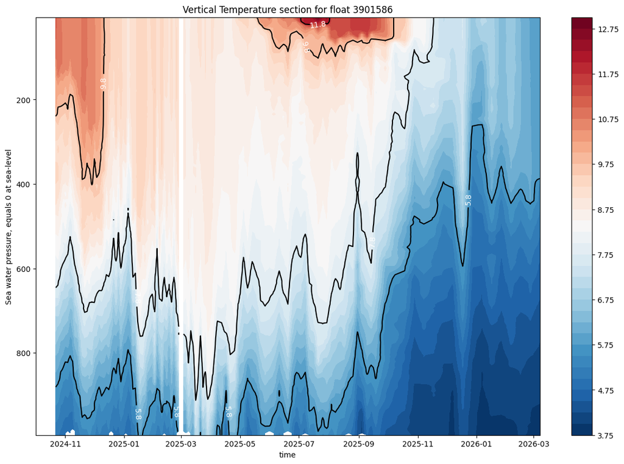

```python
fig, ax = plt.subplots(figsize=(15,10))

#Draw the contours for the salinity
cs=ax.contourf(juld,prei,tempi.transpose(),40,cmap="RdBu_r")

#Draw the contours lines to be labelled
cs2=ax.contour(juld,prei,tempi.transpose(),colors=('k'), levels=cs.levels[::8])

#Since pressure increase away from the surface we invert the y-axis
ax.invert_yaxis()
ax.clabel(cs2, fmt='%2.1f', colors='w', fontsize=10)

#Add the titles
ax.set_title(f"Vertical Temperature section for float {argo_ds.PLATFORM_NUMBER[0].astype(str).values}")
ax.set_xlabel(f"{argo_ds.JULD.standard_name}")
ax.set_ylabel(f"{argo_ds.PRES.long_name}")

#Add the colorbar
cbar=fig.colorbar(cs,ax=ax)
```

We can visualise the transect of the float with a bit more data manipulation. We will regrid the data in depth and time, and then plot the data as a 2D image.

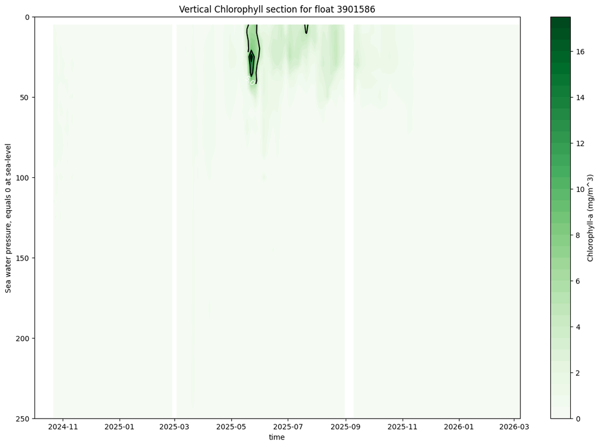

```python
fig, ax = plt.subplots(figsize=(15,10))

#Draw the contours for the salinity
cs=ax.contourf(juld,prei,chlai.transpose(),40,cmap="Greens")

#Draw the contours lines to be labelled
cs2=ax.contour(juld,prei,chlai.transpose(),colors=('k'), levels=cs.levels[::10])

#Since pressure increase away from the surface we invert the y-axis
ax.invert_yaxis()
ax.clabel(cs2, fmt='%2.1f', colors='w', fontsize=10)

#Add the titles
ax.set_title(f"Vertical Chlorophyll section for float {argo_ds.PLATFORM_NUMBER[0].astype(str).values}")
ax.set_xlabel(f"{argo_ds.JULD.standard_name}")
ax.set_ylabel(f"{argo_ds.PRES.long_name}")
ax.set_ylim([250,0])

#Add the colorbar
cbar=fig.colorbar(cs,ax=ax, label='Chlorophyll-a (mg/m^3)')
```

```python
def plot_transect(
    ds,
    varname,
    depth_max=200,
    log_transform=False,
    palette="viridis",
    vmin=None,
    vmax=None,
):
    """
    Plot a depth-vs-time transect from profile-form datasets.

    Parameters
    ----------
    ds : xarray.Dataset
        Input dataset (e.g., argo_ds)
    varname : str
        Variable to plot (e.g., 'CHLA', 'TEMP', 'NITRATE')
    depth_max : int or float
        Maximum depth (dbar) for interpolation/plotting
    log_transform : bool
        If True, apply log10 transform to positive values before plotting
    palette : str
        Matplotlib colormap name
    vmin : float or None
        Minimum colorbar limit
    vmax : float or None
        Maximum colorbar limit
    """

    if varname not in ds:
        raise KeyError(f"'{varname}' not found in dataset.")
    if "PRES" not in ds:
        raise KeyError("'PRES' not found in dataset.")
    if vmin is not None and vmax is not None and vmin >= vmax:
        raise ValueError("'vmin' must be smaller than 'vmax'.")

    time_name = "TIME" if "TIME" in ds else ("JULD" if "JULD" in ds else None)
    if time_name is None:
        raise KeyError("No time variable found. Expected 'TIME' or 'JULD'.")

    var = ds[varname].values
    pres = ds["PRES"].values
    time_vals = ds[time_name].values
    depth_grid = np.arange(0, depth_max + 1, 1)

    profiles = []
    times_unique = time_vals
    n_prof = var.shape[0]

    for i in range(n_prof):
        p = pres[i, :]
        v = var[i, :]
        m = np.isfinite(p) & np.isfinite(v)
        if m.sum() > 1:
            p_valid = p[m]
            v_valid = v[m]
            order = np.argsort(p_valid)
            p_valid = p_valid[order]
            v_valid = v_valid[order]
            p_unique, idx = np.unique(p_valid, return_index=True)
            v_interp = np.interp(depth_grid, p_unique, v_valid[idx], left=np.nan, right=np.nan)
        else:
            v_interp = np.full_like(depth_grid, np.nan, dtype=float)
        profiles.append(v_interp)

    section = np.array(profiles, dtype=float)

    if log_transform:
        section = np.where(section > 0, np.log10(section), np.nan)
        cbar_label = f"log10({varname})"
    else:
        cbar_label = varname

    if vmin is not None and vmax is not None:
        extend = "both"
    elif vmin is not None:
        extend = "min"
    elif vmax is not None:
        extend = "max"
    else:
        extend = "neither"

    plt.figure(figsize=(13, 6))
    pcm = plt.pcolormesh(
        times_unique,
        depth_grid,
        section.T,
        shading="auto",
        cmap=palette,
        vmin=vmin,
        vmax=vmax,
    )
    plt.gca().invert_yaxis()
    plt.xlabel(time_name)
    plt.ylabel("Pressure (dbar)")
    plt.title(f"{varname} transect")
    plt.colorbar(pcm, label=cbar_label, extend=extend)
    plt.tight_layout()
    plt.show()
```

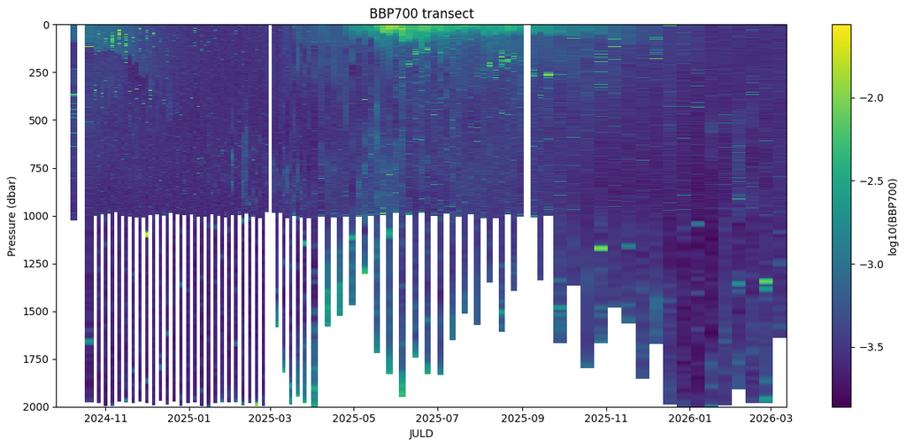

```python
plot_transect(argo_ds, "BBP700", depth_max=2000, log_transform=True)
```

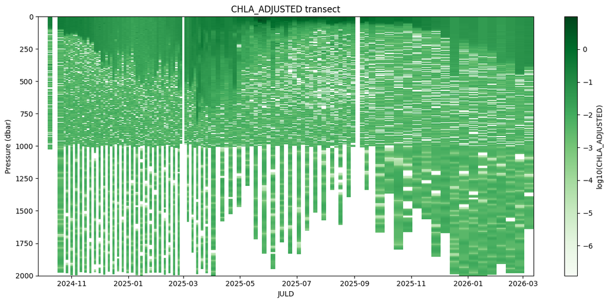

```python
plot_transect(argo_ds, "CHLA_ADJUSTED", depth_max=2000, log_transform=True, palette="Greens")
```

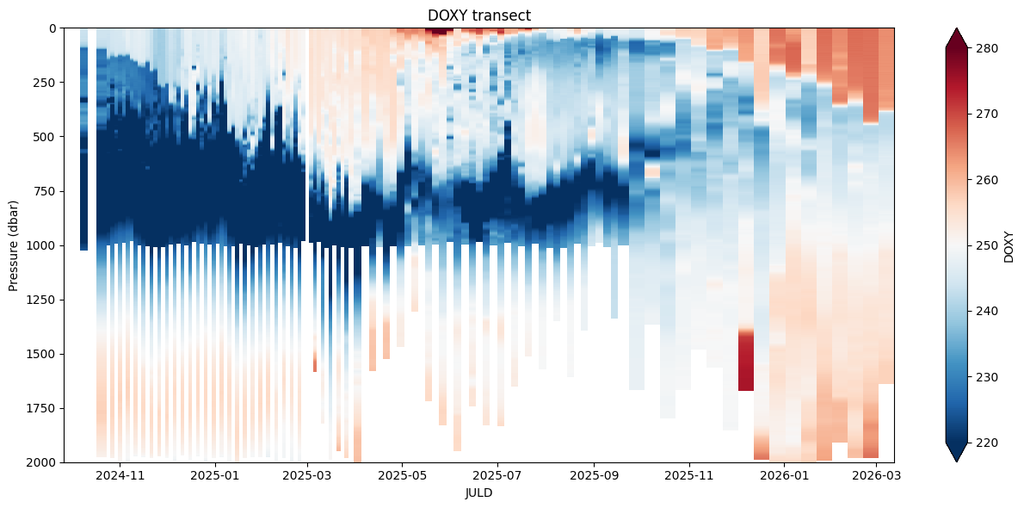

```python
plot_transect(argo_ds, "DOXY", depth_max=2000, log_transform=False, palette = "RdBu_r", vmax = 280, vmin = 220)
```

## Profile based analysis

After visualising the full float time series transect we often want to go into more details and look at discrete profiles. The PROF_NUM dimension of the SProf will be useful to do so.

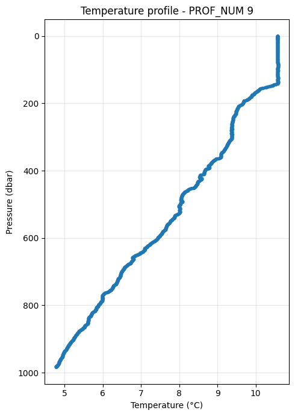

```python
# Choose any available profile number here:
profile_num = int(argo_ds["PROF_NUM"].values[10])

# Select the profile based on the PROF_NUM dimension
prof = argo_ds.sel(PROF_NUM=profile_num)

# Extract and clean data
p = prof["PRES"].values
t = prof["TEMP"].values
m = np.isfinite(p) & np.isfinite(t)

# Plot temperature profile
plt.figure(figsize=(5, 7))
plt.plot(t[m], p[m], "-o", ms=3)
plt.gca().invert_yaxis()
plt.xlabel("Temperature (°C)")
plt.ylabel("Pressure (dbar)")
plt.title(f"Temperature profile - PROF_NUM {profile_num}")
plt.grid(True, alpha=0.3)
plt.tight_layout()
plt.show()
```

Something very handy with NetCDf is the capacity to automatically label long names and units of variable. Because it is a *self describing* format, all the meta-information can be found in thee attributes. Let's build a little function that return a string with the long name of a variable and its units.

```python
def _label_from_attrs(da):
    """Extract a formatted label from the attributes of a DataArray.

    Args:
        da (_type_): The DataArray from which to extract the label.

    Returns:
        _type_: The formatted label string.
    """
    name = da.attrs.get("long_name") or da.attrs.get("standard_name") or da.name
    units = da.attrs.get("units")
    return f"{name} ({units})" if units else name

#example making a label fo temperature using the function we just defined:
_label_from_attrs(prof["TEMP"])
```

```
'Sea temperature in-situ ITS-90 scale (degree_Celsius)'
```

So, if we do the same plot as above with a cleaner label for X and Y axis

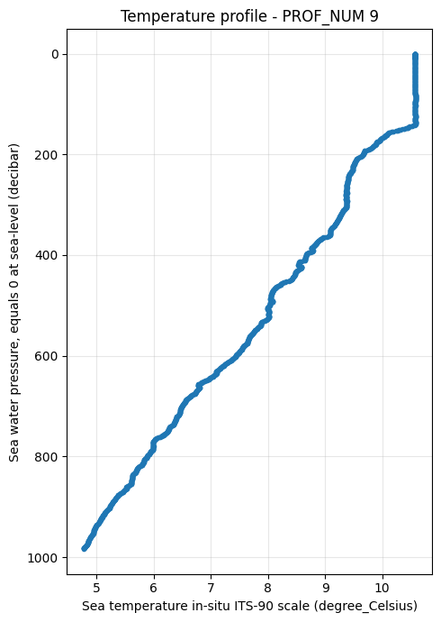

```python
# Plot temperature profile
plt.figure(figsize=(5, 7))
plt.plot(t[m], p[m], "-o", ms=3)
plt.gca().invert_yaxis()
plt.xlabel(_label_from_attrs(prof["TEMP"]))
plt.ylabel(_label_from_attrs(prof["PRES"]))
plt.title(f"Temperature profile - PROF_NUM {profile_num}")
plt.grid(True, alpha=0.3)
plt.tight_layout()
plt.show()
```

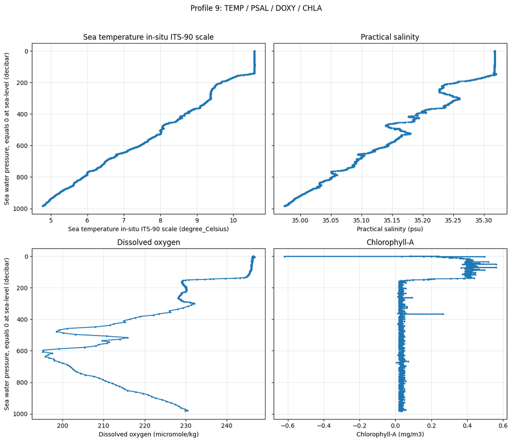

```python
# 2x2 profile grid: TEMP, PSAL, DOXY, CHLA using variable attributes for labels
vars_to_plot = ["TEMP", "PSAL", "DOXY", "CHLA"]

prof = argo_ds.sel(PROF_NUM=profile_num)

#define our 2*2 grid of subplots, sharing the y-axis (pressure) for easier comparison across variables
fig, axes = plt.subplots(2, 2, figsize=(12, 10), sharey=True)

#extract the PRESSURE var and make a Y axis label
p = prof["PRES"].values
p_label = _label_from_attrs(prof["PRES"])


#Now we through our plots grid (ax) and our variables to plot (var) in parallel,
# checking if the variable is in the profile dataset, and if so,
# plotting it against pressure.
for ax, var in zip(axes.ravel(), vars_to_plot):
    if var in prof:
        x = prof[var].values
        m = np.isfinite(p) & np.isfinite(x)
        ax.plot(x[m], p[m], "-o", ms=2)
        ax.set_xlabel(_label_from_attrs(prof[var]))
        ax.set_title(prof[var].attrs.get("long_name", var))
        ax.invert_yaxis()
    else:
        ax.text(0.5, 0.5, f"{var} not available", ha="center", va="center", transform=ax.transAxes)
        ax.set_title(var)

    #ax.invert_yaxis()
    ax.grid(True, alpha=0.3)

axes[0, 0].set_ylabel(p_label)
axes[1, 0].set_ylabel(p_label)

fig.suptitle(f"Profile {profile_num}: TEMP / PSAL / DOXY / CHLA", y=1.02)
plt.gca().invert_yaxis()
plt.tight_layout()
plt.show()
```

Obviously, looking for a profile by its number is not the most handy way to perform data analysis. Most of the time we want to see profile withing a giver date range. In this case, we use the same coding loging but we perform a `where` filtering on the JULD dimension. When providing a date range it is likely we will end up with multiple profiles insead of just one, so the plotting will be a bit different. We will loop through the profiles to color code by date.

```python
# Select all profiles in a date range
start_date = np.datetime64("2025-07-01")
end_date = np.datetime64("2025-12-01")
mask_time = (argo_ds["JULD"] >= start_date) & (argo_ds["JULD"] < end_date)

prof_nums_july = argo_ds["PROF_NUM"].where(mask_time, drop=True)
ds_july = argo_ds.sel(PROF_NUM=prof_nums_july)

dates = pd.to_datetime(ds_july["JULD"].values)
date_nums = mdates.date2num(dates)

cmap = plt.get_cmap("viridis")
norm = plt.Normalize(date_nums.min(), date_nums.max())

plt.figure(figsize=(6, 8))

ax = plt.gca()

# Plot each profile, colored by date
for prof_num, dnum in zip(ds_july["PROF_NUM"].values, date_nums):
    prof = ds_july.sel(PROF_NUM=prof_num)

    p = prof["PRES"].values
    t = prof["TEMP"].values
    m = np.isfinite(p) & np.isfinite(t)

    ax.plot(t[m], p[m], "-", color=cmap(norm(dnum)), lw=1.5, alpha=0.9)

ax.invert_yaxis()
ax.set_xlabel(_label_from_attrs(ds_july["TEMP"]))
ax.set_ylabel(_label_from_attrs(ds_july["PRES"]))
ax.set_title("Temperature profiles - Summer 2025")
ax.grid(True, alpha=0.3)

# Color guide
sm = plt.cm.ScalarMappable(cmap=cmap, norm=norm)
sm.set_array([])
cbar = plt.colorbar(sm, ax=ax, pad=0.02, ticks=np.unique(date_nums))
cbar.set_label("Profile date")
cbar.ax.yaxis.set_major_formatter(mdates.DateFormatter("%d %b %Y"))

plt.tight_layout()
plt.show()
```

[output not shown]

[output not shown]

```python
# Variables you want to plot
vars_to_plot = ["TEMP", "PSAL", "DOXY", "CHLA"]  # change as needed

# Select profiles in date range
start_date = np.datetime64("2025-07-01")
end_date   = np.datetime64("2025-12-01")

mask_time = (argo_ds["JULD"] >= start_date) & (argo_ds["JULD"] < end_date)

prof_nums = argo_ds["PROF_NUM"].where(mask_time, drop=True)
ds_sel = argo_ds.sel(PROF_NUM=prof_nums)

dates = pd.to_datetime(ds_sel["JULD"].values)
date_nums = mdates.date2num(dates)

# Shared colormap / normalization
cmap = plt.get_cmap("viridis")
norm = plt.Normalize(date_nums.min(), date_nums.max())

# Create grid
fig, axes = plt.subplots(2, 2, figsize=(10, 10), sharey=True)
axes = axes.ravel()

for ax, var in zip(axes, vars_to_plot):

    for prof_num, dnum in zip(ds_sel["PROF_NUM"].values, date_nums):
        prof = ds_sel.sel(PROF_NUM=prof_num)

        p = prof["PRES"].values
        v = prof[var].values

        m = np.isfinite(p) & np.isfinite(v)

        ax.plot(v[m], p[m],
                "-", color=cmap(norm(dnum)),
                lw=1.5, alpha=0.9)

    ax.set_xlabel(_label_from_attrs(ds_sel[var]))
    ax.grid(True, alpha=0.3)
    ax.set_title(var)

# Only left plots need y-labels
axes[0].invert_yaxis()
axes[0].set_ylabel(_label_from_attrs(ds_sel["PRES"]))
axes[2].set_ylabel(_label_from_attrs(ds_sel["PRES"]))

# Shared colorbar
# Create space on the right for the colorbar
fig.subplots_adjust(right=0.88)

# Dedicated axis for colorbar  → [left, bottom, width, height]
cax = fig.add_axes([0.90, 0.15, 0.02, 0.7])

sm = plt.cm.ScalarMappable(cmap=cmap, norm=norm)
sm.set_array([])

cbar = fig.colorbar(sm, cax=cax)
cbar.set_label("Profile date")
cbar.ax.yaxis.set_major_formatter(
    mdates.DateFormatter("%d %b %Y")
)
plt.show()
```

[output not shown]

## Fecthing BGC-Argo data on a given location

Now that we know how to look for a specific BGC-Argo float and how to extract its data, metadata and QC we can start doing analysis on entire regions based on the same coding practice !

A few caveats come into place though :

- Merging different BGC-Argo dataset can be tricky since the depth levels will be different
- The cycle timing can be different
- You may not have the same variable combination (sensor payloads) and the floats you've fetched

Happily for us, again, **Argopy** tried to solved most of those issues !

We will first need to define our fetching criteria :

A box with longitude, latitude, date and depth boundaries.

```python
with ar.set_options(ds='bgc'):
    f = ar.DataFetcher(params='DOXY').region([-35, -20, 55, 70,0, 100, '2024-05', '2024-10'])
```

Before loading the entire dataset into memory you can already see what float you have in your fecthing box with the `plot` functions of argopy.

```
(<Figure size 900x540 with 1 Axes>,
 <GeoAxes: xlabel='longitude', ylabel='latitude'>)
```

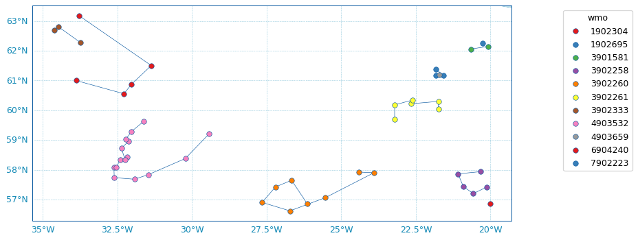

```python
f.plot()
```

Now, depending on the box you've chosen you can see that you have one or several floats in your location.

```python
dat = f.to_xarray()
```

```python
display(dat)
```

[output not shown]

- The *dimensions* are changed
- The *Coordinates* are also changed
- The *JULD* variable is now a *TIME* variable.